[figure not shown]

WI-457

Door Cord RH

WIRING SYSTEM

72.Door Cord RH

A: LOCATION

Connector Connecting to

No. Pole Color Area No. Description

AB63 2 C-2 R124 Rear wiring harness RH

AB64 2 Y C-3 Front door impact sensor RH

D1 8 C-1 B30 Bulkhead wiring harness

D12

2 C-2 Front door speaker RH (standard model)

2 C-2 Front door speaker RH (premium model)

D13 6 GR C-2 Front power window motor RH

D15 10 C-2 Outer mirror assembly RH

D17 8 C-2 Front power window sub-switch

D18 10 B-3 Front door lock actuator RH

D28 8 B-3 R13 Rear wiring harness RH

D29

2 C-3 Rear door speaker RH (standard model)

2 C-3 Rear door speaker RH (premium model)

D30 6 GR B-4 Rear power window motor RH

D31 8 B-4 Rear power window switch RH

D32 10 A-4 Rear door lock actuator RH

D56 6 B-3 Outer handle RH

D83 28 C-2 i76 Instrument panel wiring harness

D125 5 C-2 Passenger’s seat door lock switch

: White or natural color

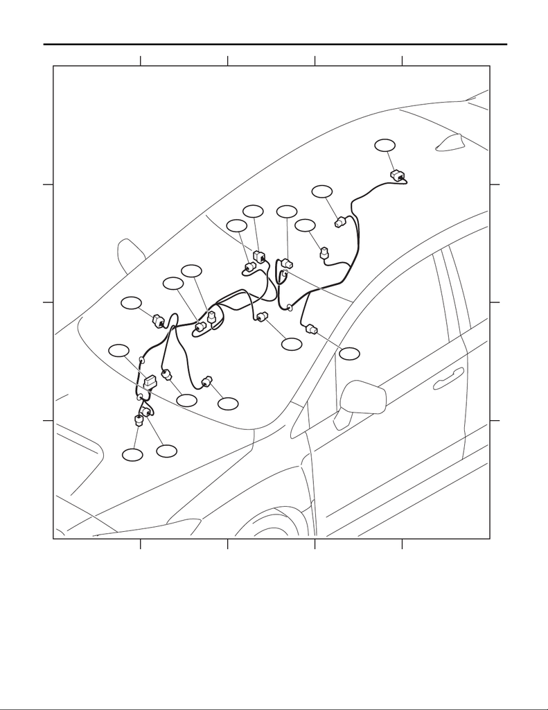

WI-458

Door Cord RH

WIRING SYSTEM

WI-44627

12345

12345

A

B

C

D

A

B

C

D

D56

AB64

D29

D18

D28

D30

D31

D32

D125

D15

D17

D83

D12

D13

AB63

D1